# Derive final annotations based on NBAtlas reference

Stephanie J. Spielman

2025-08-14

In this analysis module, we have annotated cell types in `SCPCP000004` samples using two methods: `SingleR` and `scANVI/scArches`, both using the `NBAtlas` dataset as a reference. In this notebook, we derive the final annotations using information from the `SingleR` labels, the `scANVI/scArches` labels, and existing consensus cell type annotations. All final annotations use labels present in the `NBAtlas` dataset.

We use the following approach to determine the final annotation.

First, we prioritize inferences with `SingleR` and `scANVI/scArches`. If these methods returned the exact same label, we assign this label.

Next, we compare labels across all three methods: if at least *two out of three* methods agree, we assign the agreeing label. Note that this requires mapping consensus cell types to NBAtlas labels, which is only possible for these cell types: endothelial cells, fibroblasts, and immune cell types except for the `NBAtlas` labels `RBCs` and `pDC` which do not have corresponding consensus labels.

In this approach, there are two ways that cell type annotations can agree, and we treat them as follows:

- Cell type annotations can have directly corresponding labels. For example:
  - If the consensus cell type is `endothelial cell` and at least one of the `NBAtlas`-derived annotations is `Endothelial`, we assign the label `Endothelial`.
- Cell type annotations can differ but be in the same “family” of cell types. For example:
  - If the consensus cell type is `mature T cell` and at least one of the `NBAtlas`-derived annotations is `CD4+ T cell`, we assign the broader label `T cell`.
  - If one `NBAtlas`-derived annotation is `Patrolling monocyte` and the other is `Classical monocyte`, we assign the broader label `Monocyte`.

Finally, to the extent possible, we assign CL ontology IDs to the final annotations before export.

## Setup

```r
suppressPackageStartupMessages({
  library(ggplot2)
  library(patchwork)
  library(SingleCellExperiment)
})

theme_set(
  theme_bw() +
  theme(
    axis.text = element_blank(),
    axis.ticks = element_blank(),
    legend.position = "bottom",
    aspect.ratio = 1
  )
)

# settings
options(
  dplyr.summarise.inform = FALSE,
  readr.show_col_types = FALSE
)
```

### Functions

The function `get_unified_label()` defined in the chunk below determines a final label based on correspondence between at least two out of three labels, out of `SingleR`, `scANVI/scArches`, and the consensus label.

```r
#' Get unified cell type label
#'
#' @param annotation_df Data frame to annotate with columns `consensus`, `singler`, `scanvi`, and `cell_type_assignment`
#' @param consensus_options Vector of consensus cell types that match the final label, used for `consensus`
#' @param nbatlas_options Vector of NBAtlas cell types that match the final label, used for `singler` and `scanvi`
#' @param final_label Final label to apply if at least two methods have labels present in their respective vectors
#'
#' @returns Updated annotation_df with `cell_type_assignment` filled in with the `final_label` value where appropriate
get_unified_label <- function(
    annotation_df,
    consensus_options,
    nbatlas_options,
    final_label) {

  annotation_df |>
    dplyr::mutate(
      # count how many annotations are in agreement
      n = consensus %in% consensus_options +
        singler %in% nbatlas_options +
        scanvi %in% nbatlas_options,
      # if >=2 agree, use this annotation
      cell_type_assignment = ifelse(
        is.na(cell_type_assignment) & n >= 2,
        final_label,
        cell_type_assignment
    )) |>
    dplyr::select(-n)
}
```

### Paths

```r
module_dir <- rprojroot::find_root(rprojroot::is_renv_project)
repository_base <- file.path(module_dir, "..", "..")

data_dir <- file.path(repository_base, "data", "current", "SCPCP000004")
merged_dir <- file.path(repository_base, "data", "current", "results", "merge-sce", "SCPCP000004")
ref_dir <- file.path(module_dir, "references")
results_dir <- file.path(module_dir, "results")
singler_dir <- file.path(results_dir, "singler")
scanvi_dir <- file.path(results_dir, "scanvi")
```

```r
# merged SCE file
sce_file <- file.path(
  merged_dir,
  "SCPCP000004_merged.rds"
)

# SingleR files
singler_files <- list.files(
  path = singler_dir,
  pattern = "_singler-annotations\\.tsv",
  recursive = TRUE,
  full.names = TRUE
) |>
  # add names as library id
  purrr::set_names(
    \(x) {
      stringr::str_remove(basename(x), "_singler-annotations.tsv")
    }
  )

# scanvi predictions
scanvi_file <- file.path(
  scanvi_dir,
  "scanvi-predictions.tsv"
)

# palette file
palette_file <- file.path(
  module_dir,
  "palettes",
  "nbatlas-cell-type-palette.tsv"
)

# label map file
nbatlas_label_map_file <- file.path(
  ref_dir,
  "nbatlas-label-map.tsv"
)

# label ontologies file
nbatlas_ontology_file <- file.path(
  ref_dir,
  "nbatlas-ontology-ids.tsv"
)

validation_url <- "https://raw.githubusercontent.com/AlexsLemonade/OpenScPCA-analysis/refs/heads/main/analyses/cell-type-consensus/references/consensus-validation-groups.tsv"
```

### Read and prepare input data

Read merged SCE object:

```r
merged_sce <- readRDS(sce_file)
# immediately remove assays we don't need for space
assay(merged_sce, "spliced") <- NULL
assay(merged_sce, "counts") <- NULL
reducedDim(merged_sce, "PCA") <- NULL
```

Read SingleR results:

```r
singler_df <- singler_files |>
  purrr::map(readr::read_tsv) |>
  purrr::list_rbind(names_to = "library_id") |>
  dplyr::mutate(
    # add cell id column for unique rows & joining
    cell_id = glue::glue("{library_id}-{barcodes}"),
    # recode NA -> "Unknown"
    singler = ifelse(is.na(pruned.labels), "Unknown", pruned.labels)
  ) |>
  dplyr::select(cell_id, singler)
```

Read scANVI results:

```r
scanvi_df <- readr::read_tsv(
  file.path(scanvi_dir, "scanvi_predictions.tsv")
) |>
  dplyr::select(
    cell_id,
    scanvi = scanvi_prediction,
    starts_with("pp_")
  ) |>
  tidyr::pivot_longer(
    starts_with("pp_"),
    names_to = "posterior_celltype",
    values_to = "posterior"
  ) |>
  dplyr::mutate(posterior_celltype = stringr::str_remove(posterior_celltype, "^pp_")) |>
  dplyr::filter(scanvi == posterior_celltype) |>
  # recode to Unknown if below the threshold
  dplyr::mutate(scanvi = ifelse(posterior < params$scanvi_pp_threshold, "Unknown", scanvi)) |>
  dplyr::select(cell_id, scanvi)
```

Read additional helper files:

```r
validation_df <- readr::read_tsv(validation_url)

palette_df <- readr::read_tsv(palette_file)
celltype_pal <- palette_df$hex_color
names(celltype_pal) <- palette_df$NBAtlas_label

nbatlas_label_map <- readr::read_tsv(nbatlas_label_map_file)
nbatlas_ontology_ids <- readr::read_tsv(nbatlas_ontology_file)
```

Combine annotations into a single data frame:

```r
celltype_df <- scuttle::makePerCellDF(
  merged_sce,
  use.coldata = c("sample_id", "is_xenograft", "consensus_celltype_annotation")
) |>
  tibble::rownames_to_column("cell_id") |>
  tidyr::separate(cell_id, into = c("library_id", "cell_barcode"), remove = FALSE) |>
  # keep UMAP for eventual viz
  dplyr::rename(
    consensus = consensus_celltype_annotation,
    UMAP1 = UMAP.1,
    UMAP2 = UMAP.2
  ) |>
  dplyr::left_join(singler_df, by = "cell_id") |>
  dplyr::left_join(scanvi_df, by = "cell_id")


# Pull out metadata we'll want later
sample_metadata <- celltype_df |>
  dplyr::select(sample_id, library_id, is_xenograft) |>
  unique()

# We can remove the merged_sce now
rm(merged_sce)
```

Define closely-related groups of cell types that will be used for resolving annotations:

```r
#### Vectors of closely-related NBAtlas immune cell types
nbatlas_t_celltypes <- nbatlas_label_map |>
  dplyr::filter(NBAtlas_label == "T cell") |>
  dplyr::pull(NBAtlas_label_immune_zoom)

nbatlas_nk_celltypes <- nbatlas_label_map |>
  dplyr::filter(NBAtlas_label == "NK cell") |>
  dplyr::pull(NBAtlas_label_immune_zoom)

nbatlas_myeloid_celltypes <- nbatlas_label_map |>
  dplyr::filter(NBAtlas_label == "Myeloid") |>
  dplyr::pull(NBAtlas_label_immune_zoom)

# Note that cDC and Monocyte are not direct labels in the disseminated NBAtlas object,
# but these groupings are used in the paper's marker gene analysis.
nbatlas_cdc_celltypes <- nbatlas_label_map |>
  dplyr::filter(NBAtlas_label == "cDC") |>
  dplyr::pull(NBAtlas_label_immune_zoom)

nbatlas_monocyte_celltypes <- nbatlas_label_map |>
  dplyr::filter(NBAtlas_label == "Monocyte") |>
  dplyr::pull(NBAtlas_label_immune_zoom)

#### Vectors of closely-related consensus cell types
consensus_t_celltypes <- validation_df |>
  dplyr::filter(validation_group_annotation == "T cell") |>
  dplyr::pull(consensus_annotation)

consensus_endo_celltypes <- validation_df |>
  dplyr::filter(validation_group_annotation == "endothelial cell") |>
  dplyr::pull(consensus_annotation)

consensus_myeloid_celltypes <- validation_df |>
  dplyr::filter(
    # consider only groups corresponding to what NBAtlas breaks up
    # the Myeloid group into in the tumor zoom
    validation_group_annotation %in% c("myeloid", "monocyte", "macrophage")
  )|>
  dplyr::pull(consensus_annotation)
```

## Annotate

In this section, we’ll derive the final annotations.

First, we’ll label any cells that have exactly matching `scANVI` and `SingleR` labels.

```r
annotation_df <- celltype_df |>
  dplyr::select(cell_id, consensus, singler, scanvi) |>
  dplyr::mutate(
    cell_type_assignment = ifelse(
      scanvi == singler, scanvi, NA
    )
  )
```

Next, we’ll get unified labels for any cells where at least two of three methods agree.

```r
annotation_df <- annotation_df |>
  get_unified_label("fibroblast", "Fibroblast", "Fibroblast") |>
  get_unified_label("macrophage", "Macrophage", "Macrophage") |>
  get_unified_label("neutrophil", "Neutrophil", "Neutrophil") |>
  get_unified_label("plasma cell", "Plasma", "Plasma") |>
  get_unified_label(consensus_endo_celltypes, "Endothelial", "Endothelial") |>
  get_unified_label("natural killer cell", nbatlas_nk_celltypes, "NK cell") |>
  get_unified_label("monocyte", nbatlas_monocyte_celltypes, "Monocyte") |>
  get_unified_label("dendritic cell", nbatlas_cdc_celltypes, "cDC") |>
  get_unified_label(consensus_t_celltypes, nbatlas_t_celltypes, "T cell") |>
  # This must be last since it is the broadest category
  get_unified_label(consensus_myeloid_celltypes, nbatlas_myeloid_celltypes, "Myeloid")
```

## Explore final annotations

What fraction of cells have been annotated?

```r
sum(!is.na(annotation_df$cell_type_assignment)) / nrow(annotation_df)
```

```
[1] 0.8582383
```

What fraction of cells have been annotated per library?

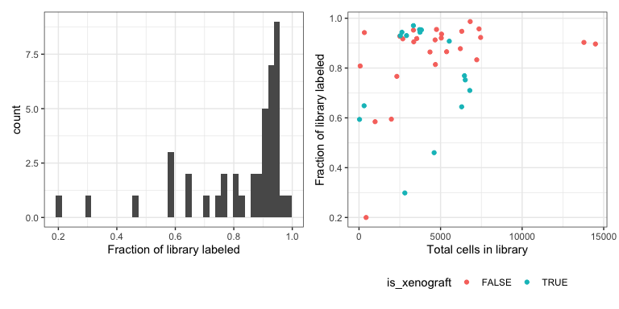

```r
frac_labeled_df <- annotation_df |>
  tidyr::separate(cell_id, into = c("library_id", "barcode"), remove = FALSE) |>
  dplyr::group_by(library_id) |>
  dplyr::summarize(
    frac_labeled = sum(!is.na(cell_type_assignment))/dplyr::n(),
    library_size = dplyr::n()
  ) |>
  # get PDX logical for coloring
  dplyr::inner_join(sample_metadata, by = "library_id")


p1 <- ggplot(frac_labeled_df) +
  aes(x = frac_labeled) +
  geom_histogram(bins = 40) +
  labs(x = "Fraction of library labeled") +
  theme_bw()


p2 <- ggplot(frac_labeled_df) +
  aes(x = library_size, y = frac_labeled, color = is_xenograft) +
  geom_point() +
  labs(
    x = "Total cells in library",
    y = "Fraction of library labeled"
  ) +
  theme_bw() +
  theme(legend.position = "bottom")


p1 + p2
```

### UMAPs

In this section, we show the UMAP from the merged (not batch-corrected!) `SCPCP000004` object colored by cell type annotations and other potentially relevant metadata.

```r
# Finalize the annotations
submission_df <- annotation_df |>
  # add ontology ids
  dplyr::left_join(
    nbatlas_ontology_ids,
    by = c("cell_type_assignment" = "NBAtlas_label")
  ) |>
  # recode labels
  dplyr::mutate(
    cell_type_assignment = dplyr::case_when(
      is.na(cell_type_assignment) ~ "Unknown",
      cell_type_assignment == "NE" ~ "Neuroendocrine/tumor",
      .default = cell_type_assignment
   ),
    tumor_cell_classification = dplyr::case_when(
      cell_type_assignment == "Unknown" ~ "Unknown",
      cell_type_assignment == "Neuroendocrine/tumor" ~ "tumor",
      .default = "normal"
    )
  ) |>
  tidyr::separate(cell_id, into = c("library_id", "cell_barcode"), remove = FALSE) |>
  dplyr::select(
    cell_id, library_id, cell_barcode, cell_type_assignment, tumor_cell_classification, CL_ontology_id
  )
# update palette label as well
names(celltype_pal)[names(celltype_pal) == "Neuroendocrine"] <- "Neuroendocrine/tumor"
```

```r
# prepare data frame for plotting
umap_df <- celltype_df |>
  dplyr::select(cell_id, sample_id, library_id, is_xenograft, UMAP1, UMAP2) |>
  dplyr::left_join(submission_df, by = "cell_id") |>
  # group "same family" cell types in the factor for cleaner legend
  # note this will give warnings if any of those cells aren't in the final annotation, but that's fine
  dplyr::mutate(
    cell_type_assignment = factor(cell_type_assignment),
    cell_type_assignment = forcats::fct_relevel(
      cell_type_assignment,
      "T cell", nbatlas_t_celltypes,
      "NK cell", nbatlas_nk_celltypes,
      "cDC", nbatlas_cdc_celltypes,
      "Monocyte", nbatlas_monocyte_celltypes
    )
  )
```

#### Colored by cell type assignment

Note that in the UMAP below, cell types in the same “family” each share a color:

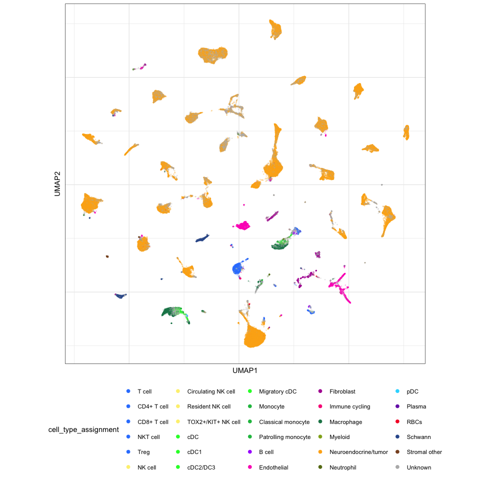

```r
ggplot(umap_df) +
  aes(x = UMAP1, y = UMAP2, color = cell_type_assignment) +
  geom_point(alpha = 0.2, size = 0.3) +
  scale_color_manual(values = celltype_pal) +
guides(color = guide_legend(override.aes = list(size = 2, alpha = 1)))
```

#### Colored by tumor classification

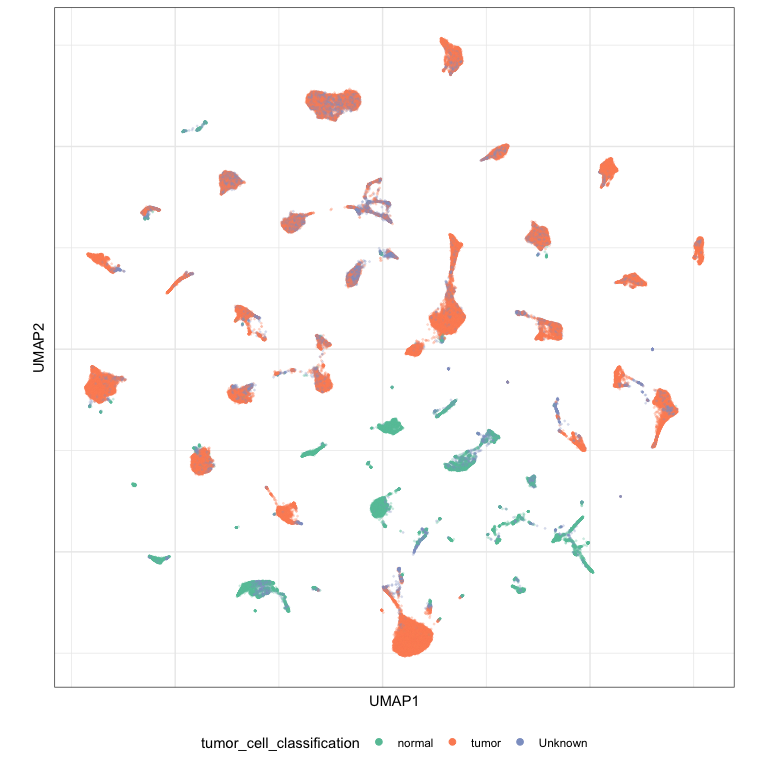

```r
ggplot(umap_df) +
  aes(x = UMAP1, y = UMAP2, color = tumor_cell_classification) +
  geom_point(alpha = 0.2, size = 0.3) +
  scale_color_brewer(palette = "Set2") +
  guides(color = guide_legend(override.aes = list(size = 2, alpha = 1)))
```

#### Colored by PDX status

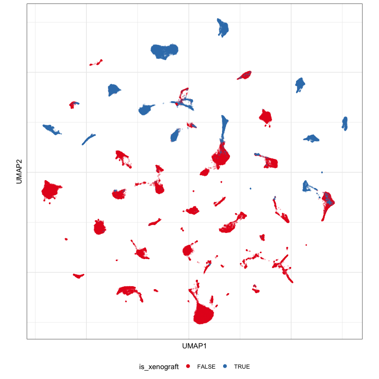

```r
ggplot(umap_df) +
  aes(x = UMAP1, y = UMAP2, color = is_xenograft) +
  geom_point(alpha = 0.2, size = 0.3) +
  scale_color_brewer(palette = "Set1") +
  guides(color = guide_legend(override.aes = list(size = 2, alpha = 1)))
```

## Export

```r
readr::write_tsv(
  submission_df,
  params$annotations_tsv
)
```